# **Bat Acoustic Survey Results**

Report produced 23 August, 2022

### Thank you for your participation in the North American Bat Monitoring Program (NABat)!

### **10 bat species were detected in 2021** across all survey locations in this report. Read on to learn more about which species were found where.

## **Map of Survey Locations**

This map shows the survey locations included in this report and the NABat cell(s) that they fall within. Hover your cursor over the map to see the NABat GRTS cell number(s) and survey location name(s).

[interactive chart not shown]

## **Species Detected**

### Bat species confirmed in 2021

An X indicates that the species was detected; blank if the species was not detected.

| Species | NABat Cell 106 SW_FowlerFence | NABat Cell 106 SW_FowlerField |
| --- | --- | --- |
| Big Brown Bat | X | X |
| Silver-haired Bat | X | X |
| Californian Myotis | X | X |
| Little Brown Myotis |  |  |
| Canyon Bat | X |  |
| Brazilian Free-tailed Bat | X | X |
| Yuma Myotis | X | X |
| Pallid Bat |  | X |
| Western Red Bat | X | X |
| Hoary Bat | X |  |
| Townsend's Big-eared Bat |  | X |

### Bat species confirmed all years

This table shows which years each bat species was detected at each location.

| Species | NABat Cell 106 NE_HiddenFalls | NABat Cell 106 SW_FowlerFence | NABat Cell 106 SW_FowlerField |
| --- | --- | --- | --- |
| Big Brown Bat | 2020 | 2020, 2021 | 2020, 2021 |
| Silver-haired Bat | 2020 | 2021 | 2021 |
| Californian Myotis | 2020 | 2021 | 2021 |
| Little Brown Myotis | 2020 | Not detected | Not detected |
| Canyon Bat | 2020 | 2021 | Not detected |
| Brazilian Free-tailed Bat | 2020 | 2020, 2021 | 2021 |
| Yuma Myotis | Not detected | 2020, 2021 | 2020, 2021 |
| Pallid Bat | Not detected | Not detected | 2020, 2021 |
| Western Red Bat | Not detected | 2021 | 2021 |
| Hoary Bat | Not detected | 2021 | Not detected |
| Townsend's Big-eared Bat | Not detected | Not detected | 2021 |

## **Photos of Species Detected**

[output not shown]

## **Species Count**

Number of bat species confirmed at each site in each year of surveying.

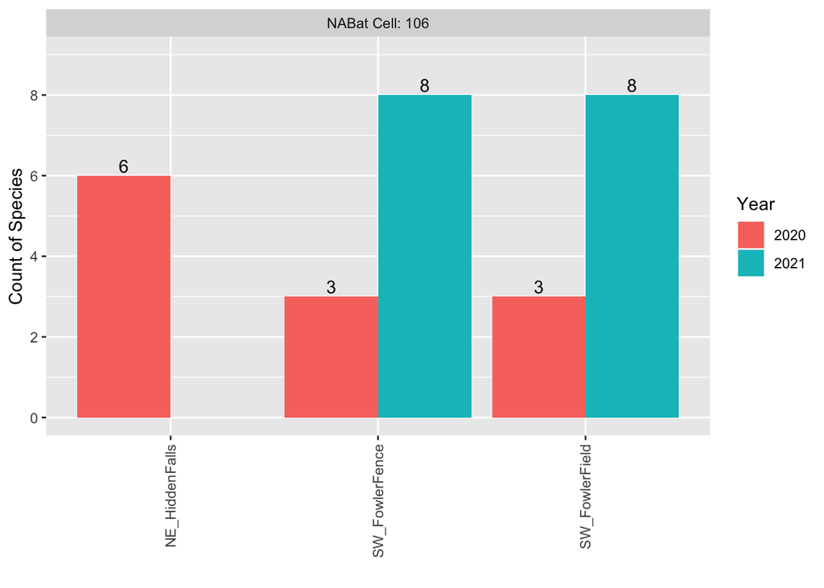

## **Survey Dates**

| NABat Cell | Location Name | Survey Start Date | Survey End Date |
| --- | --- | --- | --- |
| 106 | SW_FowlerFence | 2021-06-10 | 2021-06-13 |
|  | SW_FowlerField | 2021-06-10 | 2021-06-12 |

## **Background**

Our region’s bats face unprecedented threats, including widespread habitat alteration and destruction, climate change and drought, and the arrival and spread of a deadly fungal disease called White-nose Syndrome. Yet little is known about the current abundance and distribution of most US bat species. NABat brings together a diverse and extensive network of partners in collecting data to assess the status and trends of bat populations throughout North America to inform the conservation and management of bats. Participation by private landowners is critical to the success of effective bat population monitoring in our region as many of our highest priority survey locations occur on private land.

There are over 1,400 bat species in the world, with California and Nevada being home to 25. Our region’s bats play important ecological roles that are vital to the health of our natural ecosystems and our human economies. Scientists estimate that insect-eating bats may save U.S. farmers roughly $23 billion each year by reducing crop damage and limiting the need for pesticides, as they eat up to half of their body weight in insects each night.

Bats are difficult to observe and identify because they are most active at night and roost in small spaces. However, using “bat acoustic detectors”, we can record the echolocation calls of bats as they travel and forage for food during the night. The recordings can then be used to identify the species of the bats present in an area.

## **Methods**

NABat divides North America into a grid of 10 x 10 km squares and randomly assigns a priority ranking to every square, which is used to determine which areas to target for surveying. Exact survey locations within the 10 x 10 km squares are then selected by biologists to target areas with high expected bat activity. Bat acoustic detectors are placed near landscape features that may attract bats, such as water, dead trees, barns, open space, and forest edges.

The detectors are deployed to record for four consecutive nights. Once collected, the recorded echolocation calls are identified to the species level using auto-identification software and suspected species are then confirmed through expert review by Bat Conservation International staff. Data are then contributed to the NABat database and used to estimate habitat occupancy and population trends to guide wildlife management efforts.

Below is an example sonogram that shows a string of bat pulses. A sonogram is a graph of the frequency of sound emitted over time. Bats typically emit calls at very high frequencies. So high, that in many cases, their calls can’t be heard by the human ear. Looking at the sonograms of bat echolocation sequences allows us to “hear” with our eyes. Below is the echolocation sequence of a hoary bat (*Lasiurus cinereus*). You can see each echolocation pulse made by the bat as a colored streak on the sonogram.

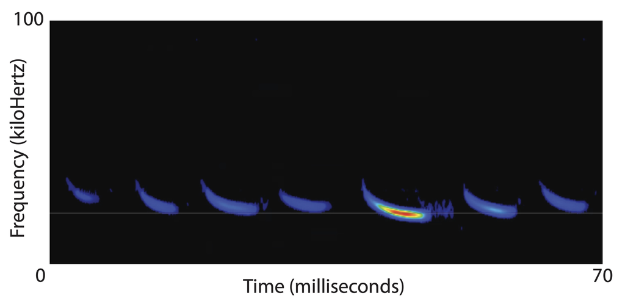

## **Learn More**

The PacWest Bat Hub coordinates NABat efforts throughout California & Nevada. The PacWest Bat Hub is managed by Bat Conservation International in collaboration with the NABat Coordinating Office, US Fish and Wildlife Service, California Department of Fish & Wildlife, and the Nevada Department of Wildlife.

To learn more about the North American Bat Monitoring Program visit [nabatmonitoring.org](https://www.nabatmonitoring.org/).

To learn more about the PacWest Bat Hub visit [pacwestbats.org](https://www.pacwestbats.org/).

To learn more about bats and to support their conservation visit [batcon.org](https://www.batcon.org/).

You can report bat colonies and bat roosting sites to the California Department of Fish and Wildlife [here](https://wildlife.ca.gov/Conservation/Mammals/Bats/Report-Colony). Knowing where bats roost helps CDFW to prioritize surveillance efforts, monitor population trends, and protect California’s bats.

[figure not shown]

[figure not shown]